```r
# loading libraries

library(ggplot2)
library(glue)
library(tidyverse)
library(gridExtra)
```

```r
# plot settings

std_width  <- 12
std_height <- 8
options(repr.plot.width = std_width, repr.plot.height = std_height)
```

```r
# plot colours

color_palette <- c( "#58508d",
                    "#bc5090",
                    "#ff6361",
                    "#ffa600" )
```

# Exercise 1: binomial inference

Study the binomial inference for a study that reports $y = 7$ successes in $n = 20$ independent trials. Assume the following priors:

1. a uniform distribution
2. a Jeffrey's prior
3. a step function defined as

$$ g(\pi) = \begin{cases} \pi & \pi \le 0.2 \\ 0.2 & 0.2 < \pi \le 0.3 \\ 0.5 - \pi & 0.3 < \pi \le 0.5 \\ 0 & \pi > 0.5 \end{cases} $$

#### 1. Plot the posterior distribution and summarize the results computing the first two moments

From Bayes' theorem, the posterior distribution for $\pi$, that is the probability of having success, can be expressed as

$$ P(\pi\,|\,n, \,y, \,H) = \frac{P(y\,|\,\pi, \,n, \,H) P(\pi\,|\,H)}{P(y\,|\,n,\,H)} $$

where in our case $y = 7$ is our data, the number of successes that has been observed, $n = 20$ is the number of independent trials, and $H$ is our hypothesis that the process follows a binomial distribution.

The appropriate likelihood is a binomial distribution with $y$ successes in $n$ independent trials, and $\pi$ the probability of success:

$$ \text{Bn}(y | \pi,n,H) = \binom{n}{y}\pi^y(1-\pi)^{n-y}$$

If the prior is a **uniform** distribution $\mathcal{U}[0,1]$, **the posterior** distribution has the same form as the likelihood, that **is a binomial**. However, the posterior and the likelihood are the same only in the shape, because the likelihood is a function of our data, meanwhile the posterior is a function of the parameter $\pi$ of our model, i.e., the hypothesis that the process follows a binomial distribution where $\pi$ is the probability of success.

So, the posterior distribution can be expressed as:

$$ P(\pi|n,y,H) = \frac{1}{Z}\,\pi^y(1-\pi)^{n-y}$$

where $Z$ is the normalization factor, i.e., the *evidence*, that we have to compute (recalling that a PDF has to be normalized to 1) and does not depend on $\pi$. Moreover, $\pi \in [0,1]$, because it is a probability.

Finally, the mode is at $\frac{y}{n}$ and in our case it is $\frac{7}{20}$.

```r
# CASE OF UNIFORM PRIOR

# number of independent trials
n <- 20
# successes
y <- 7

# probability
deltap <- 10^(-4)
p <- seq(0, 1, deltap)

# posterior distribution
post1 <- dbinom(y, n, p)
```

```r
# normalization factor
Z <- integrate(function(x) dbinom(y,n,x), 0,1)

# normalizing the posterior distribution
post1 <- post1 / Z$value
```

We then compute the first two moments (expectation value and variance) of the posterior distribution properly integrating it:

$$ E[X] = \int_0^1 \pi \, P(\pi|n,y,H) \, d\pi $$$$ var[X] = \int_0^1 (\pi-E[X])^2 \, P(\pi|n,y,H) \, d\pi $$

```r
# expectation value

m1 <- integrate(function(x) dbinom(y, n, x)*x/Z$value, 0, 1)
cat(glue("The mean value of the probability distribution is {round(m1$value, 3)}."))

# variance

v1 <- integrate(function(x) dbinom(y, n, x)*(x-m1$value)^2/Z$value, 0, 1)
cat("\n")
cat(glue("The variance of the probability distribution is {round(v1$value, 4)}."))

# mode
mode <- 7/20
cat("\n")
cat(glue("The mode of the probability distribution is {round(mode, 3)}."))
```

[output not shown]

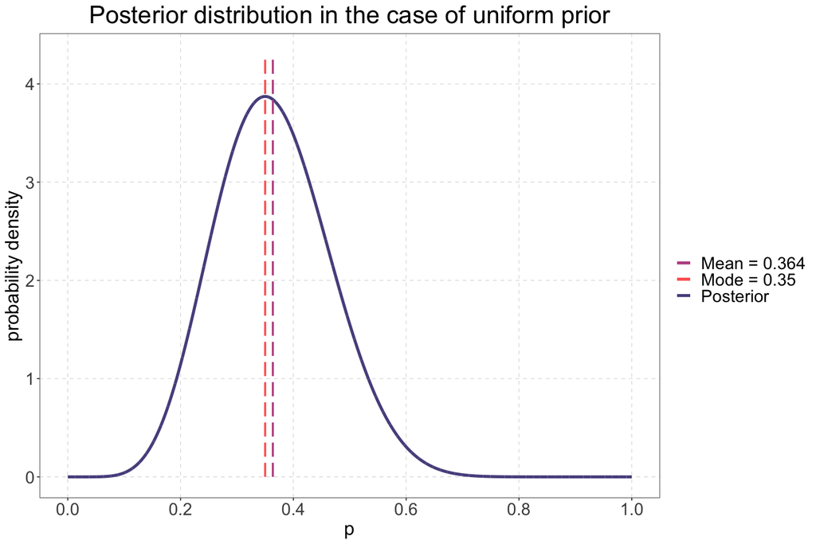

```r
plot1 <- ggplot() +
        geom_line(aes(x = p, y = post1, color = "Posterior"), linewidth = 1.5) +
        geom_segment(aes(x = m1$value, y = 0, xend = m1$value, yend = 4.3, color = "Mean = 0.364"), linetype = "longdash", linewidth = 1) +
        geom_segment(aes(x = mode, y = 0, xend = mode, yend = 4.3, color = "Mode = 0.35"), linetype = "longdash", linewidth = 1)

plot1 <- plot1 +
        theme_bw() +
        theme( legend.position = "right",
        plot.title = element_text(size = 26, hjust = 0.5),
        axis.title = element_text(size = 20),
        axis.text  = element_text(size = 18),
        legend.title = element_text(size = 20, hjust = 0.5),
        legend.text  = element_text(size = 18),
        panel.grid.major.y = element_line( color = alpha("black",0.2),
                                           linewidth = 0.3,
                                           linetype = 2 ),
        panel.grid.major.x = element_line( color = alpha("black",0.2),
                                          linewidth = 0.3,
                                          linetype = 2 ),
        panel.grid.minor = element_blank(),
        panel.background = element_blank(),
        legend.background = element_rect( fill = "white",
                                          linewidth = 0.5,
                                          linetype = "solid",
                                          colour = "white" ) ) +
        labs( x = "p",
              y = "probability density",
              title = "Posterior distribution in the case of uniform prior" ) +
        scale_color_manual(name = "",
                        values = c("Posterior" = color_palette[1], "Mean = 0.364" = color_palette[2], "Mode = 0.35" = color_palette[3])) +
        scale_x_continuous(n.breaks = 8)

plot1
```

We could also compute the posterior by interpretating the uniform prior distribution as a Beta distribution with parameters $\alpha = \beta = 1$. The Beta distribution for $\pi$ is defined as:

$$ P(\pi | y,n,H) = \frac{1}{B(\alpha, \beta)} \pi^{\alpha -1} (1-\pi)^{\beta -1} $$

where $B(\alpha, \beta)$ is the *beta function*, a normalization constant to ensure that the total probability is 1, so a Beta distribution is by definition normalized.

Moreover, the expectation value for the beta distribution is:

$$ E[X] = \frac{\alpha}{\alpha + \beta}$$

and the variance is

$$ var[X] = \frac{\alpha \,\beta}{(\alpha+\beta)^2 \, (\alpha + \beta + 1) } $$

The mode of the beta distribution is:

$$ \text{mode} = \frac{\alpha -1}{\alpha + \beta -2} $$

By multiplying a Beta prior with a binomial likelihood, since the Beta prior is the *conjugate prior* for this likelihood, we get a Beta distribution for the posterior with parameters $$\alpha = \alpha_{prior} + y = 1 + 7 = 8$$ and $$ \beta = \beta_{prior} + n - y = 1 + 20 - 7 = 14 $$

```r
# beta posterior parameters
alpha0 <- 8
beta0 <- 14

# posterior
post0 <- dbeta(p, alpha0, beta0)
```

In this case, the expectation value and the variance are:

$$ E[X] = \frac{\alpha}{\alpha + \beta} = \frac{8}{8+14} = \frac{8}{22}$$$$ var[X] = \frac{\alpha \,\beta}{(\alpha+\beta)^2 \, (\alpha + \beta + 1) } = \frac{8 \cdot 14}{22^2\, \cdot 23} $$

```r
# mean
m0 <- alpha0/(alpha0+beta0)
m00 <- integrate(function(x) dbeta(x, alpha0, beta0) * x, 0, 1)
cat(glue("The mean value of the probability distribution from theory is {round(m0, 3)}."))
cat("\n")
cat(glue("The mean value of the probability distribution is {round(m00$value, 3)}."))

# variance
v0 <- alpha0*beta0/( (alpha0+beta0)^2 * (alpha0+beta0+1))
v00 <- integrate(function(x) dbeta(x, alpha0, beta0) * (x-m00$value)^2, 0, 1)
cat("\n")
cat("\n")
cat(glue("The variance of the probability distribution from theory is {round(v0, 4)}."))
cat("\n")
cat(glue("The variance of the probability distribution is {round(v00$value, 4)}."))

# mode
mode0 <- (alpha0 - 1) / (alpha0 + beta0 - 2)
cat("\n")
cat(glue("The mode of the probability distribution is {round(mode0, 3)}."))
```

[output not shown]

As expected, the mean value and the mode are the same as in the previous case.

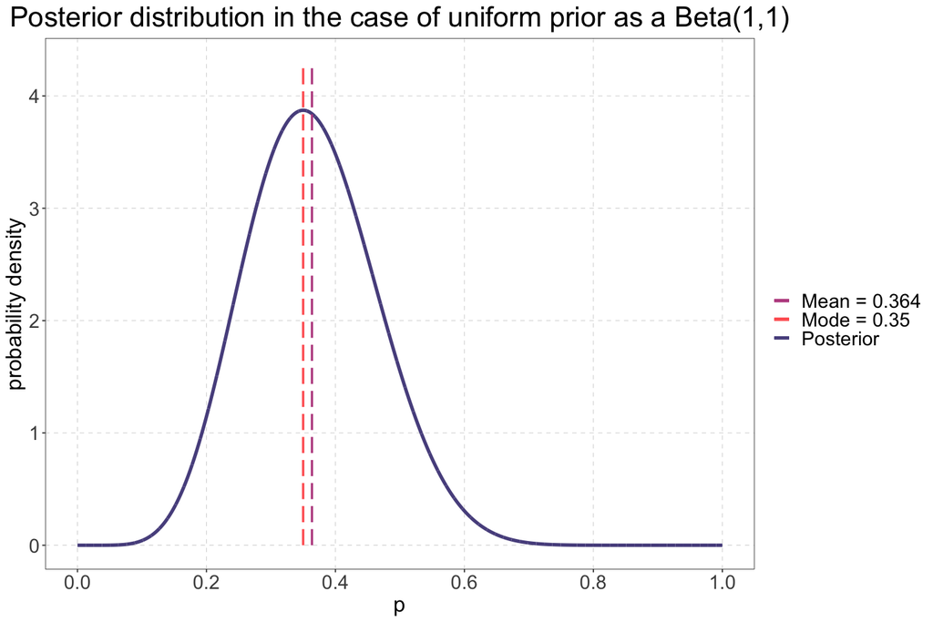

```r
plot0 <- ggplot() +
        geom_line(aes(p, post0, color = "Posterior"), linewidth = 1.5) +
        geom_segment(aes(x = m00$value, y = 0, xend = m00$value, yend = 4.3, color = "Mean = 0.364"), linetype = "longdash", linewidth = 1) +
        geom_segment(aes(x = mode0, y = 0, xend = mode0, yend = 4.3, color = "Mode = 0.35"), linetype = "longdash", linewidth = 1)

plot0 <- plot0 +
        theme_bw() +
        theme( legend.position = "right",
        plot.title = element_text(size = 26, hjust = 0.5),
        axis.title = element_text(size = 20),
        axis.text  = element_text(size = 18),
        legend.title = element_text(size = 20, hjust = 0.5),
        legend.text  = element_text(size = 18),
        panel.grid.major.y = element_line( color = alpha("black",0.2),
                                           linewidth = 0.3,
                                           linetype = 2 ),
        panel.grid.major.x = element_line( color = alpha("black",0.2),
                                          linewidth = 0.3,
                                          linetype = 2 ),
        panel.grid.minor = element_blank(),
        panel.background = element_blank(),
        legend.background = element_rect( fill = "white",
                                          linewidth = 0.5,
                                          linetype = "solid",
                                          colour = "white" ) ) +
        labs( x = "p",
              y = "probability density",
              title = "Posterior distribution in the case of uniform prior as a Beta(1,1)" ) +
        scale_color_manual(name = "",
                        values = c("Posterior" = color_palette[1], "Mean = 0.364" = color_palette[2], "Mode = 0.35" = color_palette[3])) +
        scale_x_continuous(n.breaks = 8)

plot0
```

**Jeffereys prior** for a Bernoulli trial is a Beta distribution with $\alpha = \beta = \frac{1}{2}$:

$$ P(\pi | y,n,H) = \frac{1}{B(1/2, 1/2)} \sqrt{\pi (1-\pi)} $$

and we have $E[X] = \frac{1}{2}.$

Our likelihood is a binomial distribution, so, combining a binomial with a Jeffereys, we obtain that **the posterior is a Beta distribution** with parameters

$$\alpha = \alpha_{prior}+y = \frac{1}{2}+7 $$

and

$$\beta = \beta_{prior} + n - y = \frac{1}{2} + 20 - 7$$

The expectation value and variance for the posterior are:

$$ E[X] = \frac{\alpha_{prior}+y}{\alpha_{prior}+\beta_{prior}+n} = \frac{1/2+7}{1/2+1/2+20} = \frac{7.5}{21} $$$$ var[X] = \frac{ (\alpha_{prior}+r) (\beta_{prior} + n - y) }{ (\alpha_{prior}+y + \beta_{prior} + n - y)^2 \, (\alpha_{prior}+r +\beta_{prior} + n - y + 1) } $$

```r
# CASE OF JEFFEREYS PRIOR

# posterior parameters
alpha <- 1/2 +7
beta <- 1/2 + 13

# posterior
post2 <- dbeta(p, alpha, beta)
```

We compute mean and variance integrating as in the previous case:

$$ E[X] = \int_0^1 \pi \, P(\pi\,|\,\alpha,\,\beta) \, d\pi $$$$ var[X] = \int_0^1 (\pi-E[X])^2 \, P(\pi\,|\,\alpha,\,\beta) \, d\pi $$

```r
# expectation value

m22 <- alpha/(alpha+beta)
m2 <- integrate(function(x) dbeta(x, alpha, beta)*x, 0, 1)
cat(glue("The mean value of the probability distribution from theory is {round(m22,3)}."))
cat("\n")
cat(glue("The mean value of the probability distribution is {round(m2$value,3)}."))


# variance

v22 <- alpha * beta / ( (alpha+beta)^2 * (alpha + beta + 1) )
v2 <- integrate(function(x) dbeta(x, alpha, beta)*(x-m2$value)^2, 0, 1)
cat("\n")
cat("\n")
cat(glue("The variance of the probability distribution from theory is {round(v22,4)}."))
cat("\n")
cat(glue("The variance of the probability distribution is {round(v2$value,4)}."))

# mode
idx <- which.max(post2)
mode_j <- p[idx]
cat("\n")
cat("\n")
cat(glue("The mode of the probability distribution is {round(mode_j, 3)}."))
```

[output not shown]

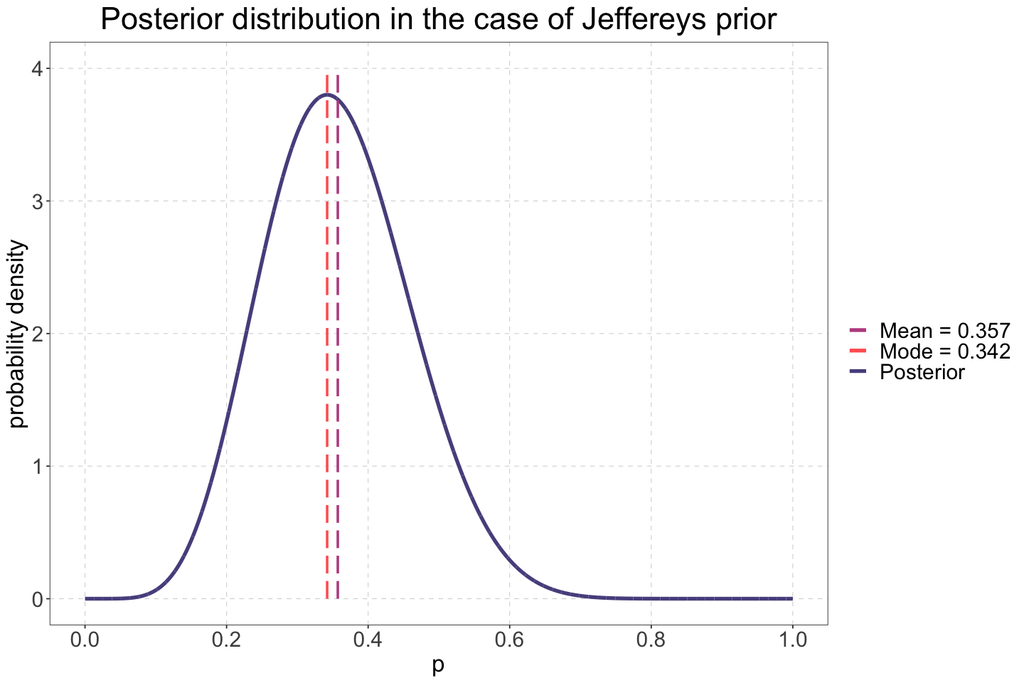

```r
plot2 <- ggplot() +
        geom_line(aes(x = p, y = post2, color = "Posterior"), linewidth = 1.5) +
        geom_segment(aes(x = m2$value, y = 0, xend = m2$value, yend = 4, color = "Mean = 0.357"), linetype = "longdash", linewidth = 1) +
        geom_segment(aes(x = mode_j, y = 0, xend = mode_j, yend = 4, color = "Mode = 0.342"), linetype = "longdash", linewidth = 1)

plot2 <- plot2 +
        theme_bw() +
        theme( legend.position = "right",
        plot.title = element_text(size = 26, hjust = 0.5),
        axis.title = element_text(size = 20),
        axis.text  = element_text(size = 18),
        legend.title = element_text(size = 20, hjust = 0.5),
        legend.text  = element_text(size = 18),
        panel.grid.major.y = element_line( color = alpha("black",0.2),
                                           linewidth = 0.3,
                                           linetype = 2 ),
        panel.grid.major.x = element_line( color = alpha("black",0.2),
                                          linewidth = 0.3,
                                          linetype = 2 ),
        panel.grid.minor = element_blank(),
        panel.background = element_blank(),
        legend.background = element_rect( fill = "white",
                                          linewidth = 0.5,
                                          linetype = "solid",
                                          colour = "white" ) ) +
        labs( x = "p",
              y = "probability density",
              title = "Posterior distribution in the case of Jeffereys prior" ) +
        scale_color_manual(name = "",
                        values = c("Posterior" = color_palette[1], "Mean = 0.357" = color_palette[2], "Mode = 0.342" = color_palette[3])) +
        scale_x_continuous(n.breaks = 8)

plot2
```

If the prior is a **step function** we have to compute the posterior numerically, multipling the likelihood by the prior.

```r
# CASE OF STEP FUNCTION PRIOR

# step prior
stepPrior <- function(p) {
    ifelse(
        p <= 0.2,
        p,
        ifelse(
            (p > 0.2) & (p <= 0.3),
            0.2,
            ifelse(
                (p > 0.3) & (p <= 0.5),
                0.5 - p,
                0
            )
        )
    )
}
```

```r
# normalization factor of the step prior (to better visualize it)
z <- sum(stepPrior(p)*deltap)
```

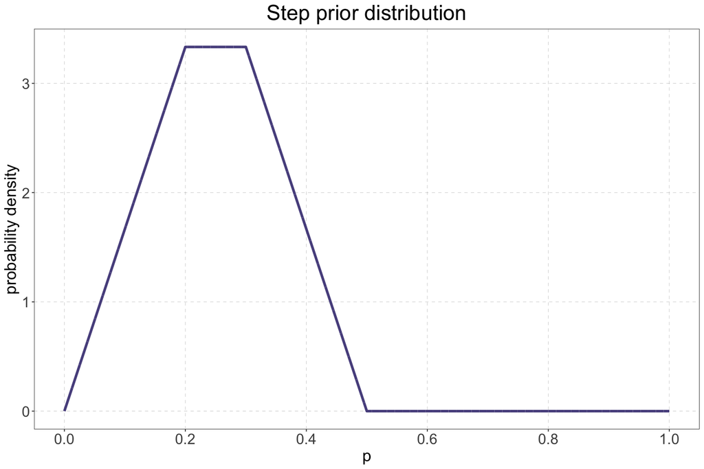

```r
# prior plot

step <- ggplot() +
        geom_line(
            aes(x = p, y = stepPrior(p)/z),
            linewidth = 1.5,
            color = color_palette[1]
            )

step <- step +
        theme_bw() +
        theme( legend.position = "right",
        plot.title = element_text(size = 26, hjust = 0.5),
        axis.title = element_text(size = 20),
        axis.text  = element_text(size = 18),
        legend.title = element_text(size = 20, hjust = 0.5),
        legend.text  = element_text(size = 18),
        panel.grid.major.y = element_line( color = alpha("black",0.2),
                                           linewidth = 0.3,
                                           linetype = 2 ),
        panel.grid.major.x = element_line( color = alpha("black",0.2),
                                          linewidth = 0.3,
                                          linetype = 2 ),
        panel.grid.minor = element_blank(),
        panel.background = element_blank(),
        legend.background = element_rect( fill = "white",
                                          linewidth = 0.5,
                                          linetype = "solid",
                                          colour = "white" ) ) +
        labs( x = "p",
              y = "probability density",
              title = "Step prior distribution" ) +
        scale_x_continuous(n.breaks = 8)

step
```

```r
# posterior

post3 <- dbinom(y, n, p) * stepPrior(p)
```

```r
# normalizing the posterior distribution
N <- sum(post3 * deltap)
post3 <- post3/N
```

We then compute mean and variance. by properly integrating the posterior distribution.

```r
# mean

m3 <- sum(post3 * p * deltap)
cat(glue("The mean value of the probability distribution is {round(m3, 3)}."))


# variance

v3 <- sum( post3 * (p-m3)^2 * deltap )
cat("\n")
cat(glue("The variance of the probability distribution is {round(v3, 3)}."))

# mode

idx_s <- which.max(post3)
mode_s <- p[idx_s]
cat("\n")
cat(glue("The mode of the probability distribution is {round(mode_s, 1)}."))
```

[output not shown]

We could have also choose this way of computing, using the `integrate` function. For example, for the mean we have:

```r
integrate(function(x) x * dbinom(y,n,x) * stepPrior(x) / (integrate(function(x) dbinom(y,n,x) * stepPrior(x), 0, 1))$value, 0, 1)
```

```
0.3120634 with absolute error < 7.3e-05
```

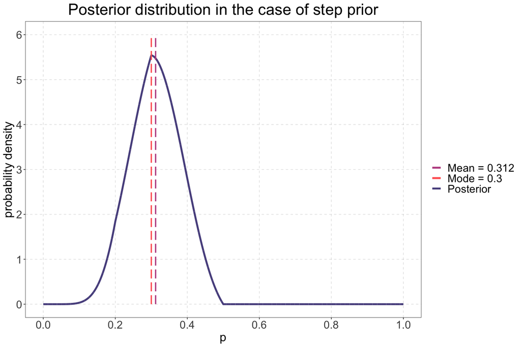

```r
# plot

plot3 <- ggplot() +
        geom_line(aes(p, post3, color = "Posterior"), linewidth = 1.5) +
        geom_segment(aes(x = m3, y = 0, xend = m3, yend = 6, color = "Mean = 0.312"), linetype = "longdash", linewidth = 1) +
        geom_segment(aes(x = mode_s, y = 0, xend = mode_s, yend = 6, color = "Mode = 0.3"), linetype = "longdash", linewidth = 1)

plot3 <- plot3 +
        theme_bw() +
        theme( legend.position = "right",
        plot.title = element_text(size = 26, hjust = 0.5),
        axis.title = element_text(size = 20),
        axis.text  = element_text(size = 18),
        legend.title = element_text(size = 20, hjust = 0.5),
        legend.text  = element_text(size = 18),
        panel.grid.major.y = element_line( color = alpha("black",0.2),
                                           linewidth = 0.3,
                                           linetype = 2 ),
        panel.grid.major.x = element_line( color = alpha("black",0.2),
                                          linewidth = 0.3,
                                          linetype = 2 ),
        panel.grid.minor = element_blank(),
        panel.background = element_blank(),
        legend.background = element_rect( fill = "white",
                                          linewidth = 0.5,
                                          linetype = "solid",
                                          colour = "white" ) ) +
        labs( x = "p",
              y = "probability density",
              title = "Posterior distribution in the case of step prior" ) +
        scale_color_manual(name = "",
                        values = c("Posterior" = color_palette[1], "Mean = 0.312" = color_palette[2], "Mode = 0.3" = color_palette[3])) +
        scale_x_continuous(n.breaks = 8) +
        scale_y_continuous(n.breaks = 6)

plot3
```

#### 2. Compute a 95% credibility interval and give the results in a summary table

We want to compute a $95\%$ CI in the three cases. We define

$$1- \alpha = 95\% \,\,\, \Rightarrow \,\,\, \alpha = 5\%$$

So, in our case, we have to find $p_{min}$, which leaves to its left the $2.5\%$ of the area of the posterior, the lower bound, and $p_{max}$, that corresponds to the upper bound, which leaves to its left the $97.5\%$ and to its right the $2.5\%$ of the area of the posterior distribution. To find these limits, we know that the CDF gives the area under the PDF until the point in which we evaluate the CDF:

$$ F(x) = \int_{-\infty}^x f(t) dt $$

with $f(x)$ as the PDF. In our case, to find $p_{min}$ we have to find $p$ so that

$$ F(p_{min}) = 2.5\% = 0.025 $$

and similarly to find $p_{max}$ we have to find $p$ so that

$$ F(p_{max}) = 97.5\% = 0.975 $$

Finally, we know that the quantile function $F^{-1}(p)$ is the inverse of the CDF, so we have

$$ F^{-1}(0.025) = p_{min} \,\,\, \Rightarrow \,\,\, p_{min} = F^{-1}\left( \frac{\alpha}{2} \right) $$

and similarly

$$ F^{-1}(0.975) = p_{max} \,\,\, \Rightarrow \,\,\, p_{max} = F^{-1}\left( 1-\frac{\alpha}{2} \right)$$

Concluding, for standard continuous distributions, we have to compute the quantile function of the poterior distribution corresponding to $\alpha/2$ and $1-\alpha/2$ to find the limits on $p$ corresponding to the CI we search for.

```r
Alpha <- 0.05
lowLim <- Alpha/2
upLim <- 1-Alpha/2
```

```r
# CASE OF UNIFORM PRIOR

pMin1 <- qbeta(lowLim, alpha0, beta0)
pMax1 <- qbeta(upLim, alpha0, beta0)
```

```r
pMin1
pMax1
```

0.181071625540173

0.569675482904124

```r
# CASE OF JEFFEREY'S PRIOR

pMin2 <- qbeta(lowLim, alpha, beta)
pMax2 <- qbeta(upLim, alpha, beta)
```

```r
pMin2
pMax2
```

0.172276213631912

0.567766093841496

```r
# CASE OF STEP PRIOR

# function to find p_min and p_max:
# it searches the index at which there is the value of p we want
# then it returns the value of p we searched for

find_p <- function( lim, posterior, probs ) {
    area_pre <- 0
    area_post <- 0
    index <- 0
    dp <- probs[2]-probs[1]

    for(i in seq(1, length(posterior), 1)) {
    area_post <- area_post + posterior[i]*dp
    if( abs(area_post - lim) > abs(area_pre - lim) ) {
        index <- i - 1
        break()
    }
    area_pre <- area_post
    }

    return(probs[index])
}
```

```r
pMin3 <- find_p(lowLim, post3, p)
pMax3 <- find_p(upLim, post3, p)
```

```r
pMin3
pMax3
```

0.1751

0.4474

Summarizing our results:

| prior | Mean | Mode | Variance | $$95\%\,\text{CI}$$ |
| --- | --- | --- | --- | --- |
| $\mathcal{U}[0,1]$ | 0.364 | 0.350 | 0.0101 | 0.181 - 0.570 |
| Jeffereys | 0.357 | 0.342 | 0.0104 | 0.172 - 0.568 |
| Step | 0.312 | 0.300 | 0.0050 | 0.175 - 0.447 |

#### 3. Draw the limits on the plot of the posterior distribution

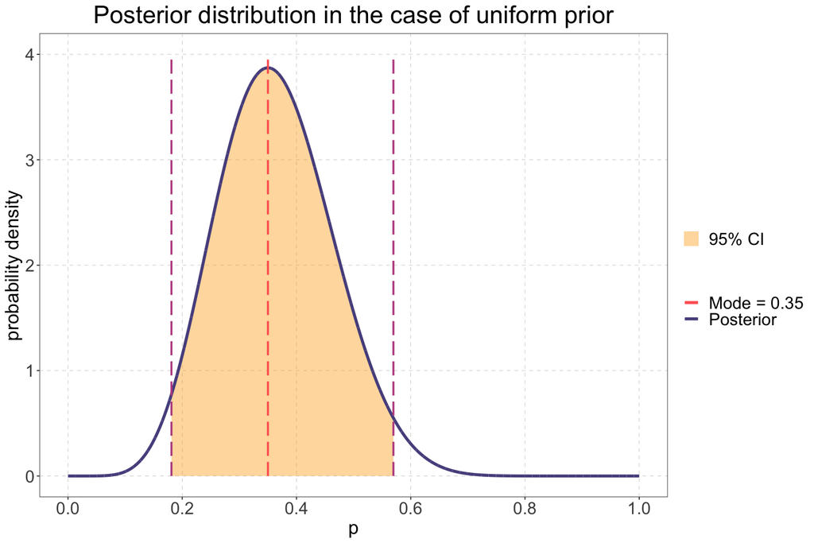

```r
# CASE OF UNIFORM PRIOR

plot11 <- ggplot() +
        geom_area(
                aes(
                    x = p[p>pMin1 & p<pMax1],
                    y = post1[p>pMin1 & p<pMax1],
                    fill = "95% CI" ),
                alpha = 0.4) +
        geom_line(
                aes(p, post1, color = "Posterior"),
                linewidth = 1.5) +
        geom_segment(
                aes(x = pMin1, y = 0, xend = pMin1, yend = 4),
                color = color_palette[2],
                linetype = "longdash",
                linewidth = 1) +
        geom_segment(
                aes(x = pMax1, y = 0, xend = pMax1, yend = 4),
                color = color_palette[2],
                linetype = "longdash",
                linewidth = 1) +
        geom_segment(
                aes(x = mode, y = 0, xend = mode, yend = 4, color = "Mode = 0.35"), linetype = "longdash", linewidth = 1)

plot11 <- plot11 +
        theme_bw() +
        theme( legend.position = "right",
        plot.title = element_text(size = 26, hjust = 0.5),
        axis.title = element_text(size = 20),
        axis.text  = element_text(size = 18),
        legend.title = element_text(size = 20, hjust = 0.5),
        legend.text  = element_text(size = 18),
        panel.grid.major.y = element_line( color = alpha("black",0.2),
                                           linewidth = 0.3,
                                           linetype = 2 ),
        panel.grid.major.x = element_line( color = alpha("black",0.2),
                                          linewidth = 0.3,
                                          linetype = 2 ),
        panel.grid.minor = element_blank(),
        panel.background = element_blank(),
        legend.background = element_rect( fill = "white",
                                          linewidth = 0.5,
                                          linetype = "solid",
                                          colour = "white" ) ) +
        labs( x = "p",
              y = "probability density",
              title = "Posterior distribution in the case of uniform prior" ) +
        scale_color_manual(name = "",
                        values = c("Posterior" = color_palette[1], "Mode = 0.35" = color_palette[3])) +
        scale_fill_manual( name = "",
                           values = c("95% CI" = color_palette[4])) +
        scale_x_continuous(n.breaks = 8)

plot11
```

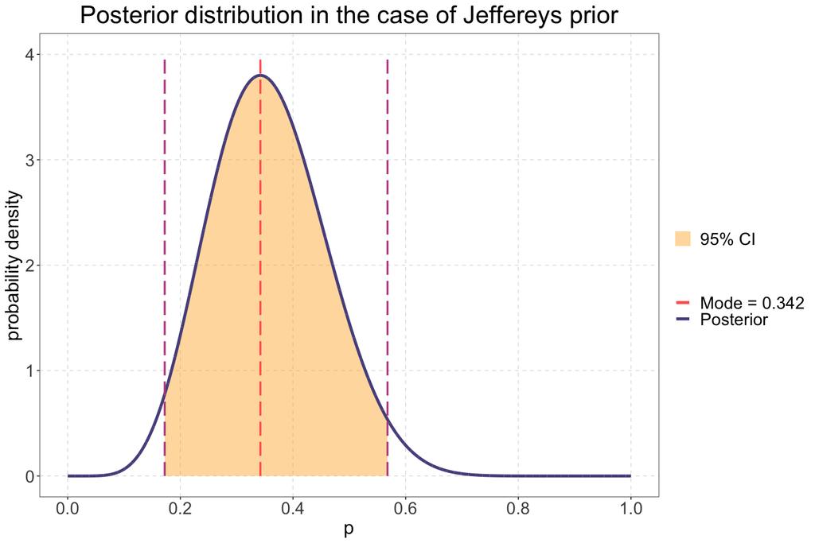

```r
# CASE OF JEFFEREYS PRIOR

plot22 <- ggplot() +
        geom_area(
                aes(
                    x = p[p>pMin2 & p<pMax2],
                    y = post2[p>pMin2 & p<pMax2],
                    fill = "95% CI" ),
                alpha = 0.4) +
        geom_line(
                aes(p, post2, color = "Posterior"), linewidth = 1.5) +
        geom_segment(
                aes(x = pMin2, y = 0, xend = pMin2, yend = 4),
                color = color_palette[2],
                linetype = "longdash",
                linewidth = 1) +
        geom_segment(
                aes(x = pMax2, y = 0, xend = pMax2, yend = 4),
                color = color_palette[2],
                linetype = "longdash",
                linewidth = 1) +
        geom_segment(
                aes(x = mode_j, y = 0, xend = mode_j, yend = 4, color = "Mode = 0.342"), linetype = "longdash", linewidth = 1)

plot22 <- plot22 +
        theme_bw() +
        theme( legend.position = "right",
        plot.title = element_text(size = 26, hjust = 0.5),
        axis.title = element_text(size = 20),
        axis.text  = element_text(size = 18),
        legend.title = element_text(size = 20, hjust = 0.5),
        legend.text  = element_text(size = 18),
        panel.grid.major.y = element_line( color = alpha("black",0.2),
                                           linewidth = 0.3,
                                           linetype = 2 ),
        panel.grid.major.x = element_line( color = alpha("black",0.2),
                                          linewidth = 0.3,
                                          linetype = 2 ),
        panel.grid.minor = element_blank(),
        panel.background = element_blank(),
        legend.background = element_rect( fill = "white",
                                          linewidth = 0.5,
                                          linetype = "solid",
                                          colour = "white" ) ) +
        labs( x = "p",
              y = "probability density",
              title = "Posterior distribution in the case of Jeffereys prior" ) +
        scale_color_manual(name = "",
                        values = c("Posterior" = color_palette[1], "Mode = 0.342" = color_palette[3])) +
        scale_fill_manual( name = "",
                           values = c("95% CI" = color_palette[4])) +
        scale_x_continuous(n.breaks = 8)

plot22
```

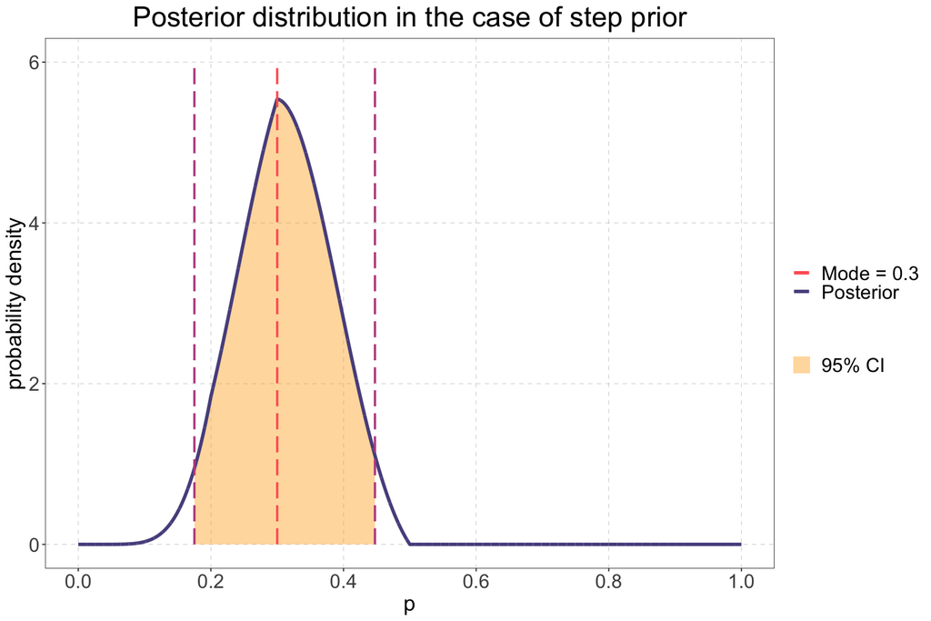

```r
# CASE OF STEP PRIOR

plot33 <- ggplot() +
        geom_area(
                aes(
                    x = p[p>pMin3 & p<pMax3],
                    y = post3[p>pMin3 & p<pMax3],
                    fill = "95% CI" ),
                alpha = 0.4) +
        geom_line(aes(p, post3, color = "Posterior"), linewidth = 1.5) +
        geom_segment(
                aes(x = pMin3, y = 0, xend = pMin3, yend = 6),
                color = color_palette[2],
                linetype = "longdash",
                linewidth = 1) +
        geom_segment(
                aes(x = pMax3, y = 0, xend = pMax3, yend = 6),
                color = color_palette[2],
                linetype = "longdash",
                linewidth = 1) +
        geom_segment(
                aes(x = mode_s, y = 0, xend = mode_s, yend = 6, color = "Mode = 0.3"), linetype = "longdash", linewidth = 1)

plot33 <- plot33 +
        theme_bw() +
        theme( legend.position = "right",
        plot.title = element_text(size = 26, hjust = 0.5),
        axis.title = element_text(size = 20),
        axis.text  = element_text(size = 18),
        legend.title = element_text(size = 20, hjust = 0.5),
        legend.text  = element_text(size = 18),
        panel.grid.major.y = element_line( color = alpha("black",0.2),
                                           linewidth = 0.3,
                                           linetype = 2 ),
        panel.grid.major.x = element_line( color = alpha("black",0.2),
                                          linewidth = 0.3,
                                          linetype = 2 ),
        panel.grid.minor = element_blank(),
        panel.background = element_blank(),
        legend.background = element_rect( fill = "white",
                                          linewidth = 0.5,
                                          linetype = "solid",
                                          colour = "white" ) ) +
        labs( x = "p",
              y = "probability density",
              title = "Posterior distribution in the case of step prior" ) +
        scale_color_manual(name = "",
                        values = c("Posterior" = color_palette[1], "Mode = 0.3" = color_palette[3])) +
        scale_fill_manual( name = "",
                           values = c("95% CI" = color_palette[4])) +
        scale_x_continuous(n.breaks = 8)

plot33
```

# Exercise 2: stream water quality

*Giardia cysts* is a parassite that can contaminate food, water, and surfaces, and they can cause giardiasis when swallowed in this infective stage of their life cycle. Infection occurs when a person swallows Giardia cysts from contaminated water, food, hands, surfaces, or objects.

A group of researchers, working for a Human Health Department, work for determining the quality of stream water: they take $n = 116$ samples of one-liter water from sites identified to have a heavy environmental impact from birds and waterflow. Out of these samples, $y = 17$ samples contained Giard cystis.

Assuming $\pi$ as the probability that one-liter water sample contains *Giardia cystis*,find the posterior distribution for $\pi$. Assume the following priors:

1. a uniform distribution
2. a $\text{Beta}(1,4)$

#### 1. Plot the posterior distribution and summarize the results compunting the first two moments

From Bayes' theorem, the posterior distribution for $\pi$ can be expressed as

$$ P(\pi\,|\,n, \,y, \,H) = \frac{P(y\,|\,\pi, \,n, \,H) P(\pi\,|\,H)}{P(y\,|\,n,\,H)} $$

where in our case $y = 17$ is our data, $n = 116$ is the number of independent trials, and $H$ is our hypothesis that the process follows a binomial distribution.

The appropriate likelihood is a binomial distribution with $y$ successes in $n$ independent trials and $\pi$ the probability of success:

$$ \text{Bn}(y | \pi,n,H) = \binom{n}{y}\pi^y(1-\pi)^{n-y}$$

If the prior is a **uniform** distribution $\mathcal{U}[0,1]$, that is a $\text{Beta}$ distribution with $\alpha = \beta = 1$, the posterior is also a $\text{Beta}$ distribution with parameters $ \alpha = 1+17 = 18$ and $\beta = 1+ 116 -17 = 100$.

```r
# beta posterior parameters
a <- 18
b <- 100

# posterior
post_unif <- dbeta(p,a,b)
```

Then, we calculate the mean and the variance both from theory and the distribution.

```r
mean_th <- a/(a+b)
var_th <- a*b/((a+b)^2*(a+b+1))
cat(glue("The expected mean value for the posterior is {round(mean_th,3)} and the expected variance is {round(var_th,4)}."))
```

```
The expected mean value for the posterior is 0.153 and the expected variance is 0.0011.
```

```r
mean <- integrate(function(x) dbeta(x, a, b) * x, 0, 1)
var <- integrate(function(x) dbeta(x,a,b) * (x-mean$value)^2, 0, 1)
cat(glue("The mean for the posterior distribution is {round(mean$value, 3)} and the variance is {round(var$value,4)}."))
```

```
The mean for the posterior distribution is 0.153 and the variance is 0.0011.
```

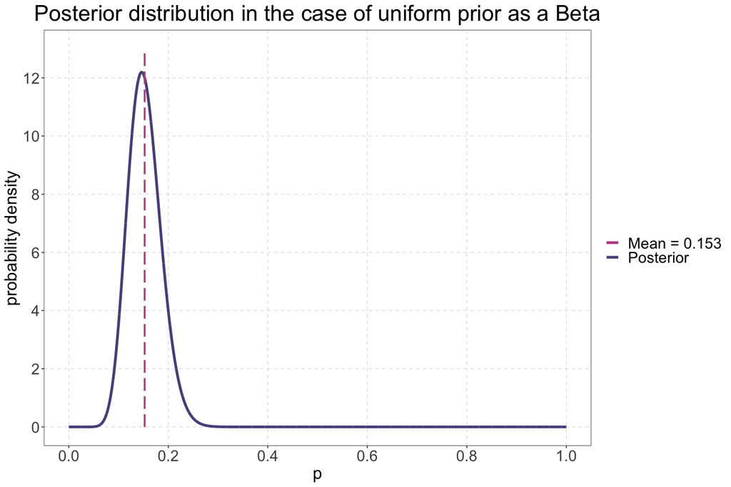

```r
# plot

plot_post <- ggplot() +
        geom_line(aes(p, post_unif, color = "Posterior"), linewidth = 1.5) +
        geom_segment(aes(x = mean$value, y = 0, xend = mean$value, yend = 13, color = "Mean = 0.153"), linetype = "longdash", linewidth = 1)

plot_post <- plot_post +
        theme_bw() +
        theme( legend.position = "right",
        plot.title = element_text(size = 26, hjust = 0.5),
        axis.title = element_text(size = 20),
        axis.text  = element_text(size = 18),
        legend.title = element_text(size = 20, hjust = 0.5),
        legend.text  = element_text(size = 18),
        panel.grid.major.y = element_line( color = alpha("black",0.2),
                                           linewidth = 0.3,
                                           linetype = 2 ),
        panel.grid.major.x = element_line( color = alpha("black",0.2),
                                          linewidth = 0.3,
                                          linetype = 2 ),
        panel.grid.minor = element_blank(),
        panel.background = element_blank(),
        legend.background = element_rect( fill = "white",
                                          linewidth = 0.5,
                                          linetype = "solid",
                                          colour = "white" ) ) +
        labs( x = "p",
              y = "probability density",
              title = "Posterior distribution in the case of uniform prior as a Beta" ) +
        scale_color_manual(name = "",
                        values = c("Posterior" = color_palette[1], "Mean = 0.153" = color_palette[2])) +
        scale_x_continuous(n.breaks = 8) +
        scale_y_continuous(n.breaks = 7)

plot_post
```

If the prior is a **$\text{Beta}$**, the posterior is then a $\text{Beta} $ distribution with parameters $\alpha = 1+17=18 $ and $\beta = 4 + 116 - 17 = 103 $.

```r
# beta posterior parameters
a_beta <- 18
b_beta <- 4+116-17

# posterior
post_beta <- dbeta(p,a_beta,b_beta)
```

Then, we calculate the mean and the variance both from theory and distribution.

```r
m_th <- a_beta/(a_beta+b_beta)
v_th <- a_beta*b_beta/((a_beta+b_beta)^2*(a_beta+b_beta+1))
cat(glue("The expected mean value for the posterior is {round(m_th,3)} and the expected variance is {round(v_th,5)}."))
```

```
The expected mean value for the posterior is 0.149 and the expected variance is 0.00104.
```

```r
m_beta <- integrate(function(x) dbeta(x, a_beta, b_beta) * x, 0, 1)
var_beta <- integrate(function(x) dbeta(x,a_beta,b_beta) * (x-m_beta$value)^2, 0, 1)
cat(glue("The mean for the posterior distribution is {round(m_beta$value, 3)} and the variance is {round(var_beta$value,5)}."))
```

```
The mean for the posterior distribution is 0.149 and the variance is 0.00104.
```

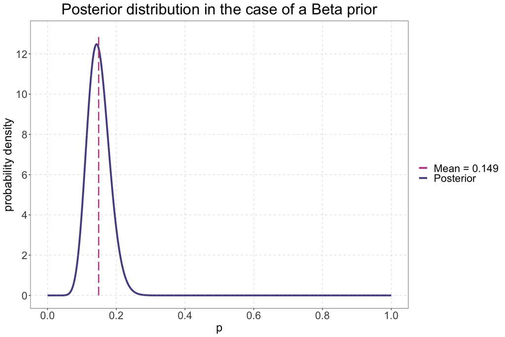

```r
# plot

plot_post_beta <- ggplot() +
        geom_line(aes(p, post_beta, color = "Posterior"), linewidth = 1.5) +
        geom_segment(aes(x = m_beta$value, y = 0, xend = m_beta$value, yend = 13, color = "Mean = 0.149"), linetype = "longdash", linewidth = 1)

plot_post_beta <- plot_post_beta +
        theme_bw() +
        theme( legend.position = "right",
        plot.title = element_text(size = 26, hjust = 0.5),
        axis.title = element_text(size = 20),
        axis.text  = element_text(size = 18),
        legend.title = element_text(size = 20, hjust = 0.5),
        legend.text  = element_text(size = 18),
        panel.grid.major.y = element_line( color = alpha("black",0.2),
                                           linewidth = 0.3,
                                           linetype = 2 ),
        panel.grid.major.x = element_line( color = alpha("black",0.2),
                                          linewidth = 0.3,
                                          linetype = 2 ),
        panel.grid.minor = element_blank(),
        panel.background = element_blank(),
        legend.background = element_rect( fill = "white",
                                          linewidth = 0.5,
                                          linetype = "solid",
                                          colour = "white" ) ) +
        labs( x = "p",
              y = "probability density",
              title = "Posterior distribution in the case of a Beta prior" ) +
        scale_color_manual(name = "",
                        values = c("Posterior" = color_palette[1], "Mean = 0.149" = color_palette[2])) +
        scale_x_continuous(n.breaks = 8) +
        scale_y_continuous(n.breaks = 7)

plot_post_beta
```

#### 2. Find a normal approximation for the posterior $g(\pi | y)$

We compute a normal approximation for the posterior both in the case of the uniform prior and in the case of the Beta prior, assuming as parameters for the normal approximation the mean and the square root of the variance of the posteriors distributions.

```r
# normal approximation in the case of uniform prior

# parameters
mu_u <- mean$value
sigma_u <- sqrt(var$value)

# normal posterior
norm_u <- dnorm(p, mu_u, sigma_u)
```

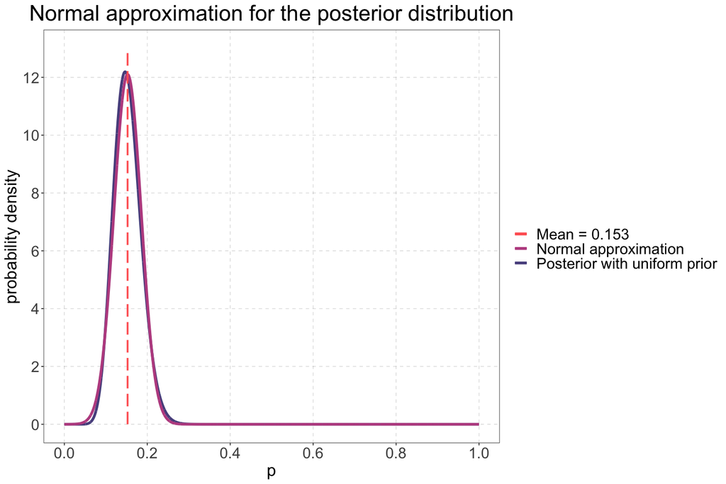

```r
# plot

norm_plot1 <- ggplot() +
        geom_line(aes(p, post_unif, color = "Posterior with uniform prior"), linewidth = 1.5) +
        geom_line(aes(p, norm_u, color = "Normal approximation"), linewidth = 1.5) +
        geom_segment(aes(x = mean$value, y = 0, xend = mean$value, yend = 13, color = "Mean = 0.153"), linetype = "longdash", linewidth = 1)

norm_plot1 <- norm_plot1 +
        theme_bw() +
        theme( legend.position = "right",
        plot.title = element_text(size = 26, hjust = 0.5),
        axis.title = element_text(size = 20),
        axis.text  = element_text(size = 18),
        legend.title = element_text(size = 20, hjust = 0.5),
        legend.text  = element_text(size = 18),
        panel.grid.major.y = element_line( color = alpha("black",0.2),
                                           linewidth = 0.3,
                                           linetype = 2 ),
        panel.grid.major.x = element_line( color = alpha("black",0.2),
                                          linewidth = 0.3,
                                          linetype = 2 ),
        panel.grid.minor = element_blank(),
        panel.background = element_blank(),
        legend.background = element_rect( fill = "white",
                                          linewidth = 0.5,
                                          linetype = "solid",
                                          colour = "white" ) ) +
        labs( x = "p",
              y = "probability density",
              title = "Normal approximation for the posterior distribution" ) +
        scale_color_manual(name = "",
                        values = c("Posterior with uniform prior" = color_palette[1], "Normal approximation" = color_palette[2], "Mean = 0.153" = color_palette[3])) +
        scale_x_continuous(n.breaks = 8) +
        scale_y_continuous(n.breaks = 7)

norm_plot1
```

```r
# normal approximation in the case of beta prior

# parameters
mu_b <- m_beta$value
sigma_b <- sqrt(var_beta$value)

# normal posterior
norm_b <- dnorm(p, mu_b, sigma_b)
```

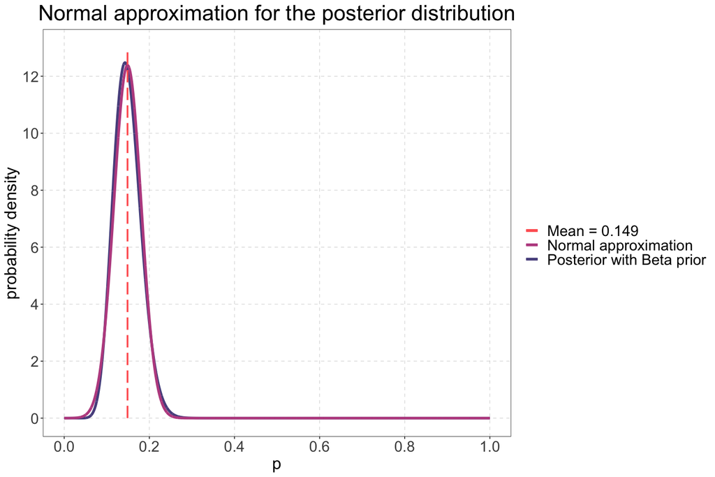

```r
# plot

norm_plot2 <- ggplot() +
        geom_line(aes(p, post_beta, color = "Posterior with Beta prior"), linewidth = 1.5) +
        geom_line(aes(p, norm_b, color = "Normal approximation"), linewidth = 1.5) +
        geom_segment(aes(x = m_beta$value, y = 0, xend = m_beta$value, yend = 13, color = "Mean = 0.149"), linetype = "longdash", linewidth = 1)

norm_plot2 <- norm_plot2 +
        theme_bw() +
        theme( legend.position = "right",
        plot.title = element_text(size = 26, hjust = 0.5),
        axis.title = element_text(size = 20),
        axis.text  = element_text(size = 18),
        legend.title = element_text(size = 20, hjust = 0.5),
        legend.text  = element_text(size = 18),
        panel.grid.major.y = element_line( color = alpha("black",0.2),
                                           linewidth = 0.3,
                                           linetype = 2 ),
        panel.grid.major.x = element_line( color = alpha("black",0.2),
                                          linewidth = 0.3,
                                          linetype = 2 ),
        panel.grid.minor = element_blank(),
        panel.background = element_blank(),
        legend.background = element_rect( fill = "white",
                                          linewidth = 0.5,
                                          linetype = "solid",
                                          colour = "white" ) ) +
        labs( x = "p",
              y = "probability density",
              title = "Normal approximation for the posterior distribution" ) +
        scale_color_manual(name = "",
                        values = c("Posterior with Beta prior" = color_palette[1], "Normal approximation" = color_palette[2], "Mean = 0.149" = color_palette[3])) +
        scale_x_continuous(n.breaks = 8) +
        scale_y_continuous(n.breaks = 7)

norm_plot2
```

In both cases we can observe that the normal approximation is a good one for the posteriors, however it is symmetrical with respect to the mean and the posteriors are slightly positively skewed.

#### 3. Compute a $95\%$ credibility interval bith for the original posterior and for the normal approximation, giving the results in a summary table

To estimate the $95\% $ CI we proceed as in the previous exercise.

```r
# CASE OF UNIFORM PRIOR

p_min1 <- qbeta(lowLim, a, b)
p_max1 <- qbeta(upLim, a, b)
```

```r
p_min1
p_max1
```

0.0938026321413977

0.222416329129256

```r
# CASE OF BETA PRIOR

p_min2 <- qbeta(lowLim, a_beta, b_beta)
p_max2 <- qbeta(upLim, a_beta, b_beta)
```

```r
p_min2
p_max2
```

0.09138957252823

0.217106898243376

```r
# NORMAL APPROXIMATION

# uniform prior
p_min3 <- qnorm(lowLim, mu_u, sigma_u)
p_max3 <- qnorm(upLim, mu_u, sigma_u)

# beta prior
p_min4 <- qnorm(lowLim, mu_b, sigma_b)
p_max4 <- qnorm(upLim, mu_b, sigma_b)
```

```r
p_min3
p_max3
p_min4
p_max4
```

0.087942917651547

0.217141828111165

0.085615519203556

0.211905141953469

Summarizing our results:

| posterior | Mean | Variance | $$95\%\,\text{CI}$$ |
| --- | --- | --- | --- |
| $\text{Beta}(18,100)$ | 0.153 | 0.0011 | 0.094 - 0.222 |
| $\text{Beta}(18,103)$ | 0.149 | 0.00104 | 0.091 - 0.217 |
| $\text{Norm}(\mu_u,\sigma_u)$ | 0.153 | 0.0011 | 0.088 - 0.217 |
| $\text{Norm}(\mu_B,\sigma_B)$ | 0.149 | 0.00104 | 0.086 - 0.212 |

#### 4. Add the limits on the plot of the posterior distributions

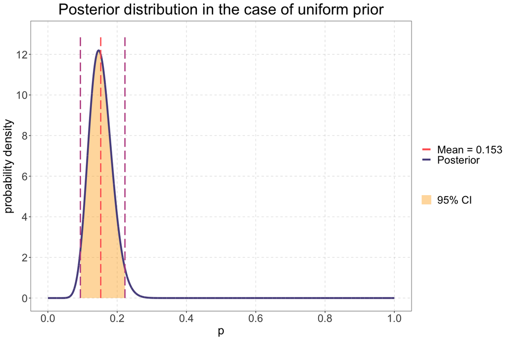

```r
# CASE OF UNIFORM PRIOR

plot_unif <- ggplot() +
        geom_area(
                aes(
                    x = p[p>p_min1 & p<p_max1],
                    y = post_unif[p>p_min1 & p<p_max1],
                    fill = "95% CI" ),
                alpha = 0.4) +
        geom_line(aes(p, post_unif, color = "Posterior"), linewidth = 1.5) +
        geom_segment(
                aes(x = p_min1, y = 0, xend = p_min1, yend = 13),
                color = color_palette[2],
                linetype = "longdash",
                linewidth = 1) +
        geom_segment(
                aes(x = p_max1, y = 0, xend = p_max1, yend = 13),
                color = color_palette[2],
                linetype = "longdash",
                linewidth = 1) +
        geom_segment(
                aes(x = mean$value, y = 0, xend = mean$value, yend = 13, color = "Mean = 0.153"), linetype = "longdash", linewidth = 1)

plot_unif <- plot_unif +
        theme_bw() +
        theme( legend.position = "right",
        plot.title = element_text(size = 26, hjust = 0.5),
        axis.title = element_text(size = 20),
        axis.text  = element_text(size = 18),
        legend.title = element_text(size = 20, hjust = 0.5),
        legend.text  = element_text(size = 18),
        panel.grid.major.y = element_line( color = alpha("black",0.2),
                                           linewidth = 0.3,
                                           linetype = 2 ),
        panel.grid.major.x = element_line( color = alpha("black",0.2),
                                          linewidth = 0.3,
                                          linetype = 2 ),
        panel.grid.minor = element_blank(),
        panel.background = element_blank(),
        legend.background = element_rect( fill = "white",
                                          linewidth = 0.5,
                                          linetype = "solid",
                                          colour = "white" ) ) +
        labs( x = "p",
              y = "probability density",
              title = "Posterior distribution in the case of uniform prior" ) +
        scale_color_manual(name = "",
                        values = c("Posterior" = color_palette[1], "Mean = 0.153" = color_palette[3])) +
        scale_fill_manual( name = "",
                           values = c("95% CI" = color_palette[4])) +
        scale_x_continuous(n.breaks = 8) +
        scale_y_continuous(n.breaks = 8)

plot_unif
```

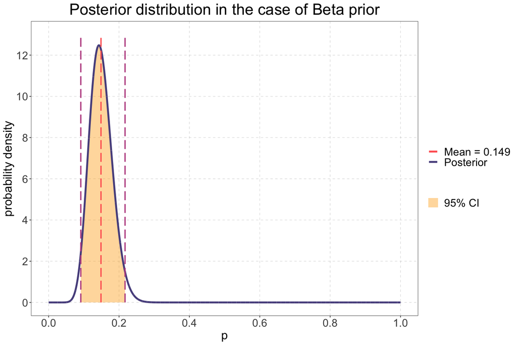

```r
# CASE OF BETA PRIOR

plot_beta <- ggplot() +
        geom_area(
                aes(
                    x = p[p>p_min2 & p<p_max2],
                    y = post_beta[p>p_min2 & p<p_max2],
                    fill = "95% CI" ),
                alpha = 0.4) +
        geom_line(aes(p, post_beta, color = "Posterior"), linewidth = 1.5) +
        geom_segment(
                aes(x = p_min2, y = 0, xend = p_min2, yend = 13),
                color = color_palette[2],
                linetype = "longdash",
                linewidth = 1) +
        geom_segment(
                aes(x = p_max2, y = 0, xend = p_max2, yend = 13),
                color = color_palette[2],
                linetype = "longdash",
                linewidth = 1) +
        geom_segment(
                aes(x = m_beta$value, y = 0, xend = m_beta$value, yend = 13, color = "Mean = 0.149"), linetype = "longdash", linewidth = 1)

plot_beta <- plot_beta +
        theme_bw() +
        theme( legend.position = "right",
        plot.title = element_text(size = 26, hjust = 0.5),
        axis.title = element_text(size = 20),
        axis.text  = element_text(size = 18),
        legend.title = element_text(size = 20, hjust = 0.5),
        legend.text  = element_text(size = 18),
        panel.grid.major.y = element_line( color = alpha("black",0.2),
                                           linewidth = 0.3,
                                           linetype = 2 ),
        panel.grid.major.x = element_line( color = alpha("black",0.2),
                                          linewidth = 0.3,
                                          linetype = 2 ),
        panel.grid.minor = element_blank(),
        panel.background = element_blank(),
        legend.background = element_rect( fill = "white",
                                          linewidth = 0.5,
                                          linetype = "solid",
                                          colour = "white" ) ) +
        labs( x = "p",
              y = "probability density",
              title = "Posterior distribution in the case of Beta prior" ) +
        scale_color_manual(name = "",
                        values = c("Posterior" = color_palette[1], "Mean = 0.149" = color_palette[3])) +
        scale_fill_manual( name = "",
                           values = c("95% CI" = color_palette[4])) +
        scale_x_continuous(n.breaks = 8) +
        scale_y_continuous(n.breaks = 8)

plot_beta
```

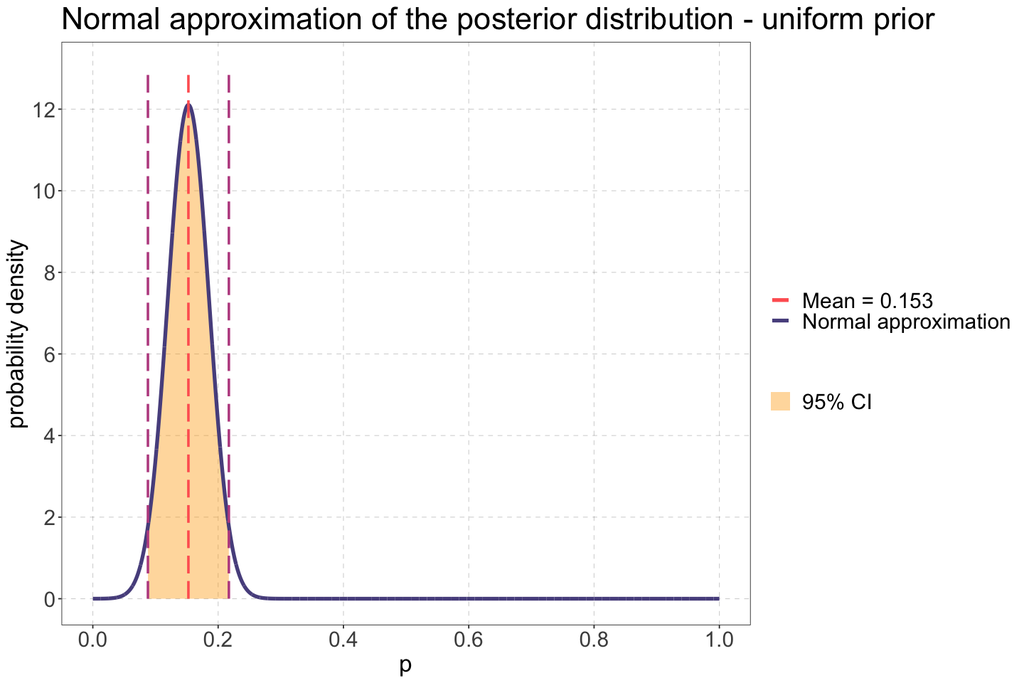

```r
# NORMAL APPROXIMATION


# uniform prior

plot_norm_u <- ggplot() +
        geom_area(
                aes(
                    x = p[p>p_min3 & p<p_max3],
                    y = norm_u[p>p_min3 & p<p_max3],
                    fill = "95% CI" ),
                alpha = 0.4) +
        geom_line(aes(p, norm_u, color = "Normal approximation"), linewidth = 1.5) +
        geom_segment(
                aes(x = p_min3, y = 0, xend = p_min3, yend = 13),
                color = color_palette[2],
                linetype = "longdash",
                linewidth = 1) +
        geom_segment(
                aes(x = p_max3, y = 0, xend = p_max3, yend = 13),
                color = color_palette[2],
                linetype = "longdash",
                linewidth = 1) +
        geom_segment(
                aes(x = mu_u, y = 0, xend = mu_u, yend = 13, color = "Mean = 0.153"), linetype = "longdash", linewidth = 1)

plot_norm_u <- plot_norm_u +
        theme_bw() +
        theme( legend.position = "right",
        plot.title = element_text(size = 26),
        axis.title = element_text(size = 20),
        axis.text  = element_text(size = 18),
        legend.title = element_text(size = 20, hjust = 0.5),
        legend.text  = element_text(size = 18),
        panel.grid.major.y = element_line( color = alpha("black",0.2),
                                           linewidth = 0.3,
                                           linetype = 2 ),
        panel.grid.major.x = element_line( color = alpha("black",0.2),
                                          linewidth = 0.3,
                                          linetype = 2 ),
        panel.grid.minor = element_blank(),
        panel.background = element_blank(),
        legend.background = element_rect( fill = "white",
                                          linewidth = 0.5,
                                          linetype = "solid",
                                          colour = "white" ) ) +
        labs( x = "p",
              y = "probability density",
              title = "Normal approximation of the posterior distribution - uniform prior" ) +
        scale_color_manual(name = "",
                        values = c("Normal approximation" = color_palette[1], "Mean = 0.153" = color_palette[3])) +
        scale_fill_manual( name = "",
                           values = c("95% CI" = color_palette[4])) +
        scale_x_continuous(n.breaks = 8) +
        scale_y_continuous(n.breaks = 8)

plot_norm_u
```

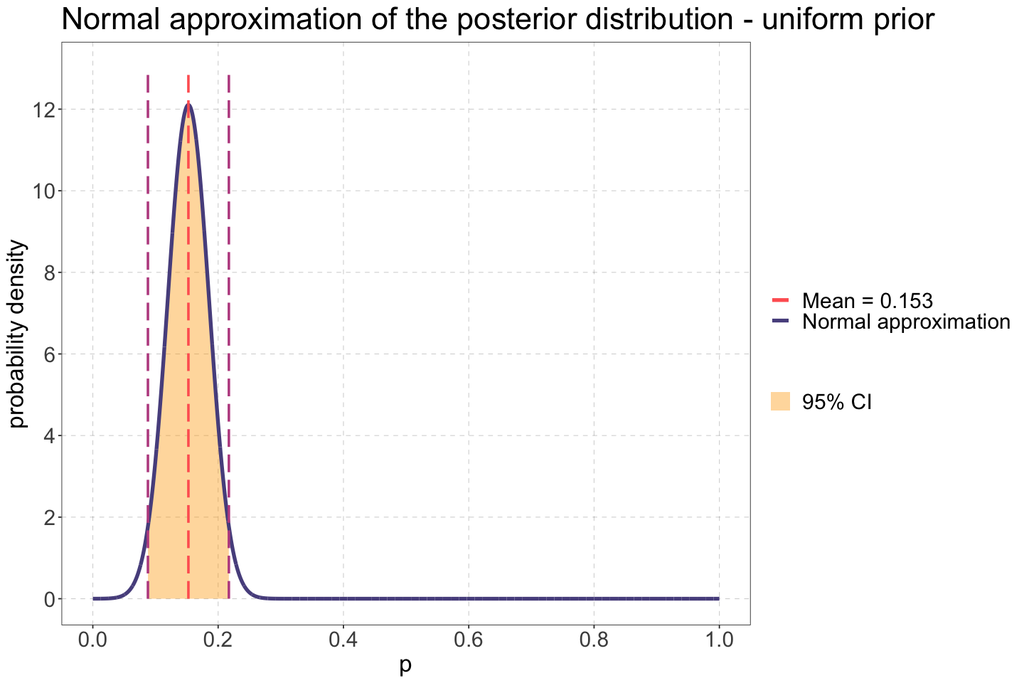

```r
# beta prior

plot_norm_b <- ggplot() +
        geom_area(
                aes(
                    x = p[p>p_min4 & p<p_max4],
                    y = norm_b[p>p_min4 & p<p_max4],
                    fill = "95% CI" ),
                alpha = 0.4) +
        geom_line(aes(p, norm_b, color = "Normal approximation"), linewidth = 1.5) +
        geom_segment(
                aes(x = p_min4, y = 0, xend = p_min4, yend = 13),
                color = color_palette[2],
                linetype = "longdash",
                linewidth = 1) +
        geom_segment(
                aes(x = p_max4, y = 0, xend = p_max4, yend = 13),
                color = color_palette[2],
                linetype = "longdash",
                linewidth = 1) +
        geom_segment(
                aes(x = mu_b, y = 0, xend = mu_b, yend = 13, color = "Mean = 0.149"), linetype = "longdash", linewidth = 1)

plot_norm_b <- plot_norm_b +
        theme_bw() +
        theme( legend.position = "right",
        plot.title = element_text(size = 26),
        axis.title = element_text(size = 20),
        axis.text  = element_text(size = 18),
        legend.title = element_text(size = 20, hjust = 0.5),
        legend.text  = element_text(size = 18),
        panel.grid.major.y = element_line( color = alpha("black",0.2),
                                           linewidth = 0.3,
                                           linetype = 2 ),
        panel.grid.major.x = element_line( color = alpha("black",0.2),
                                          linewidth = 0.3,
                                          linetype = 2 ),
        panel.grid.minor = element_blank(),
        panel.background = element_blank(),
        legend.background = element_rect( fill = "white",
                                          linewidth = 0.5,
                                          linetype = "solid",
                                          colour = "white" ) ) +
        labs( x = "p",
              y = "probability density",
              title = "Normal approximation of the posterior distribution - Beta prior") +
        scale_color_manual(
                name = "",
                values = c(
                        "Normal approximation" = color_palette[1],
                        "Mean = 0.149" = color_palette[3])
                 ) +
        scale_fill_manual( name = "",
                           values = c("95% CI" = color_palette[4])) +
        scale_x_continuous(n.breaks = 8) +
        scale_y_continuous(n.breaks = 8)

plot_norm_u
```

# Exercise 3: coin flip

A coin is flipped $n = 30$ times with the following outcomes:

T, T, T, T, T, H, T, T, H, H, T, T, H, H, H, T, H, T, H, T, H, H, T, H, T, H, T, H, H, H

#### 1. Assuming a flat prior, and a beta prior, plot the likelihood, prior and posterior distributions for the data set.

```r
nCoin <- 30

T <- 0
H <- 1

outcomes <- c(T, T, T, T, T, H, T, T, H, H, T, T, H, H, H, T, H, T, H, T, H, H, T, H, T, H, T, H, H, H)

successes <- sum(outcomes)
cat(glue("The tossing of a coin reported {successes} head and {nCoin-successes} tail."))
```

```
The tossing of a coin reported 15 head and 15 tail.
```

From Bayes' theorem, the posterior distribution for $\pi$, that is the probability of having head as outcome, can be expressed as

$$ P(\pi\,|\,n, \,y, \,H) = \frac{P(y\,|\,\pi, \,n, \,H) P(\pi\,|\,H)}{P(y\,|\,n,\,H)} $$

where in our case $y = 15$ is our data, the number of heads that has been observed, $n = 30$ is the number of independent trials, and $H$ is our hypothesis that the process follows a binomial distribution.

The appropriate likelihood is a binomial distribution with $y$ successes in $n$ independent trials, and $\pi$ the probability of head as outcome:

$$ \text{Bn}(y | \pi,n,H) = \binom{n}{y}\pi^y(1-\pi)^{n-y}$$

If the prior is a **uniform** distribution $\mathcal{U}[0,1]$, that is a $\text{Beta}$ distribution with $\alpha = \beta = 1$, the posterior is also a $\text{Beta}$ distribution with parameters $ \alpha = 1+15 = 16$ and $\beta = 1+ 30 -15 = 16$.

```r
# likelihood

likelihood <- dbinom(successes, nCoin, p)
```

```r
# normalizing likelihood (to better visualize it)
norm_l <- sum(likelihood*deltap)
```

```r
# prior

uniPrior <- dunif(p)
```

```r
# beta posterior parameters
alpha_uni <- 16
beta_uni <- 16

# posterior
post_uni <- dbeta(p, alpha_uni, beta_uni)
```

Then, we calculate the mean and the variance both from theory and the distribution.

```r
m_th_uni <- alpha_uni/(alpha_uni+beta_uni)
var_th_uni <- alpha_uni*beta_uni/((alpha_uni+beta_uni)^2*(alpha_uni+beta_uni+1))
cat(glue("The expected mean value for the posterior is {round(m_th_uni,3)} and the expected variance is {round(var_th_uni,3)}."))
```

```
The expected mean value for the posterior is 0.5 and the expected variance is 0.008.
```

```r
mean_uni <- integrate(function(x) dbeta(x, alpha_uni, beta_uni) * x, 0, 1)
var_uni <- integrate(function(x) dbeta(x,alpha_uni,beta_uni) * (x-mean_uni$value)^2, 0, 1)
cat(glue("The mean for the posterior distribution is {round(mean_uni$value, 3)} and the variance is {round(var_uni$value,3)}."))
```

```
The mean for the posterior distribution is 0.5 and the variance is 0.008.
```

```r
# plot (prior and posterior)

plot_post_uni <- ggplot() +
        geom_line(aes(p, post_uni, color = "Posterior - Beta(16,16)"), linewidth = 1.5) +
        geom_line(aes(p, uniPrior, color = "Prior - U[0,1]"), linewidth = 1.5) +
        geom_segment(aes(x = mean_uni$value, y = 0, xend = mean_uni$value, yend = 5, color = "Posterior mean = 0.5"), linetype = "longdash", linewidth = 1)

plot_post_uni <- plot_post_uni +
        theme_bw() +
        theme( legend.position = "top",
        plot.title = element_text(size = 22, hjust = 0.5),
        axis.title = element_text(size = 20),
        axis.text  = element_text(size = 18),
        legend.title = element_text(size = 20, hjust = 0.5),
        legend.text  = element_text(size = 18),
        panel.grid.major.y = element_line( color = alpha("black",0.2),
                                           linewidth = 0.3,
                                           linetype = 2 ),
        panel.grid.major.x = element_line( color = alpha("black",0.2),
                                          linewidth = 0.3,
                                          linetype = 2 ),
        panel.grid.minor = element_blank(),
        panel.background = element_blank(),
        legend.background = element_rect( fill = "white",
                                          linewidth = 0.5,
                                          linetype = "solid",
                                          colour = "white" ) ) +
        labs( x = "p",
              y = "probability density",
              title = "Posterior distribution in the case of uniform prior" ) +
        scale_color_manual(
                name = "",
                values = c(
                        "Posterior - Beta(16,16)" = color_palette[1],
                        "Prior - U[0,1]" = color_palette[3],
                        "Posterior mean = 0.5" = color_palette[4])) +
        scale_x_continuous(n.breaks = 10) +
        ylim(-0.1, 5.1)
```

```r
# plot

plot_l_uni <- ggplot() +
        geom_line(aes(p, likelihood/norm_l, color = "Bn ( x = 15 | n = 30 )"), linewidth = 1.5)

plot_l_uni <- plot_l_uni +
        theme_bw() +
        theme( legend.position = "top",
        plot.title = element_text(size = 22, hjust = 0.5),
        axis.title = element_text(size = 20),
        axis.text  = element_text(size = 18),
        legend.title = element_text(size = 20, hjust = 0.5),
        legend.text  = element_text(size = 18),
        panel.grid.major.y = element_line( color = alpha("black",0.2),
                                           linewidth = 0.3,
                                           linetype = 2 ),
        panel.grid.major.x = element_line( color = alpha("black",0.2),
                                          linewidth = 0.3,
                                          linetype = 2 ),
        panel.grid.minor = element_blank(),
        panel.background = element_blank(),
        legend.background = element_rect( fill = "white",
                                          linewidth = 0.5,
                                          linetype = "solid",
                                          colour = "white" ) ) +
        labs( x = "p",
              y = "probability density",
              title = "Likelihood distribution" ) +
        scale_color_manual(
                name = "",
                values = c(
                        "Bn ( x = 15 | n = 30 )" = color_palette[2])) +
        scale_x_continuous(n.breaks = 10) +
        ylim(-0.1, 5.1)
```

If the prior is a **Beta**, the posterior is also a Beta distribution. It is reasonable to choose Beta prior parameters as $\alpha = \beta = 1/2$ because from the data we expect $\pi = 1/2$. So we have a Jeffereys prior and the posterior parameters becomes $\alpha = 1/2 + 15$ and $\beta = 1/2 + 30 - 15 = 1/2 + 15 = \alpha$.

```r
# prior

jPrior <- dbeta(p, 1/2, 1/2)
```

```r
# beta posterior parameters
alpha_beta <- 15 + 1/2
beta_beta <- 15 + 1/2

# posterior
post_beta_coin <- dbeta(p, alpha_beta, beta_beta)
```

Then, we calculate the mean and the variance both from theory and distribution.

```r
m_th_beta <- alpha_beta/(alpha_beta+beta_beta)
v_th_beta <- alpha_beta*beta_beta/((alpha_beta+beta_beta)^2*(alpha_beta+beta_beta+1))
cat(glue("The expected mean value for the posterior is {round(m_th_beta,3)} and the expected variance is {round(v_th_beta,3)}."))
```

```
The expected mean value for the posterior is 0.5 and the expected variance is 0.008.
```

```r
mean_beta <- integrate(function(x) dbeta(x, alpha_beta, beta_beta) * x, 0, 1)
v_beta <- integrate(function(x) dbeta(x,alpha_beta,beta_beta) * (x-mean_beta$value)^2, 0, 1)
cat(glue("The mean for the posterior distribution is {round(mean_beta$value, 3)} and the variance is {round(v_beta$value,3)}."))
```

```
The mean for the posterior distribution is 0.5 and the variance is 0.008.
```

```r
# plot (prior and posterior)

plotBetaCoin <- ggplot() +
        geom_line(aes(p, post_beta_coin, color = "Posterior - Beta"), linewidth = 1.5) +
        geom_line(aes(p, jPrior, color = "Jeffereys Prior"), linewidth = 1.5) +
        geom_segment(aes(x = mean_beta$value, y = 0, xend = mean_beta$value, yend = 5, color = "Mean = 0.5"), linetype = "longdash", linewidth = 1)

plotBetaCoin <- plotBetaCoin +
        theme_bw() +
        theme( legend.position = "top",
        plot.title = element_text(size = 22, hjust = 0.5),
        axis.title = element_text(size = 20),
        axis.text  = element_text(size = 18),
        legend.title = element_text(size = 20, hjust = 0.5),
        legend.text  = element_text(size = 18),
        panel.grid.major.y = element_line( color = alpha("black",0.2),
                                           linewidth = 0.3,
                                           linetype = 2 ),
        panel.grid.major.x = element_line( color = alpha("black",0.2),
                                          linewidth = 0.3,
                                          linetype = 2 ),
        panel.grid.minor = element_blank(),
        panel.background = element_blank(),
        legend.background = element_rect( fill = "white",
                                          linewidth = 0.5,
                                          linetype = "solid",
                                          colour = "white" ) ) +
        labs( x = "p",
              y = "probability density",
              title = "Posterior distribution in the case of Beta prior (Jeffereys)" ) +
        scale_color_manual(
                name = "",
                values = c("Posterior - Beta" = color_palette[1],
                        "Mean = 0.5" = color_palette[4],
                        "Jeffereys Prior" = color_palette[3])) +
        scale_x_continuous(n.breaks = 10) +
        ylim(-0.1, 5.1)
```

```r
# adjusting plot settings
std_width  <- 9
std_height <- 13
options(repr.plot.width = std_width, repr.plot.height = std_height)
```

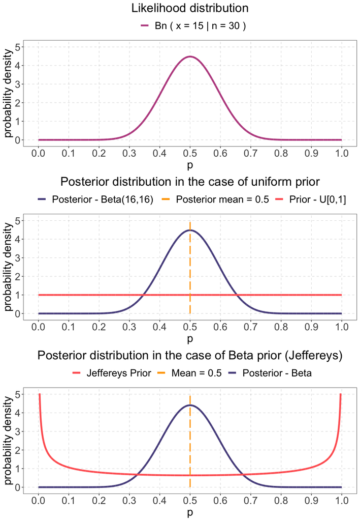

```r
grid.arrange(plot_l_uni, plot_post_uni, plotBetaCoin, ncol = 1, nrow = 3)
```

```r
# readjusting plot settings
std_width  <- 12
std_height <- 8
options(repr.plot.width = std_width, repr.plot.height = std_height)
```

#### 2. Evaluate the most probable value for the coin probability $p$ and, integrating the posterior probability distribution, give an estimate for a $95\%$ credibility interval.

The most probable value for $\pi$ is the mode of the posterior. Since $n$ is an high number, the posterior distributions are almost symmetrical and the mode are the same as the mean.

We compute the $95\%$ CI as in the other exercises.

```r
# CASE OF UNIFORM PRIOR

mode_uni <- p[which.max(post_uni)]

pmin_unif <- qbeta(lowLim, alpha_uni, beta_uni)
pmax_unif <- qbeta(upLim, alpha_uni, beta_uni)
```

```r
mode_uni
pmin_unif
pmax_unif
```

0.5

0.330605973051757

0.669394026948243

```r
# CASE OF BETA PRIOR

mode_beta <- p[which.max(post_beta_coin)]

pmin_beta <- qbeta(lowLim, alpha_beta, beta_beta)
pmax_beta <- qbeta(upLim, alpha_beta, beta_beta)
```

```r
mode_beta

pmin_beta
pmax_beta
```

0.5

0.328021355647842

0.671978644352158

#### 3. Repeat the same analysis assuming a sequential analysis of the data. Show how the most probable value and the credibility interval change as a function of the number of coin tosses (i.e. from 1 to 30).

First, I compute the posterior probability distribution in case of 1 toss. Then, I compute the posterior in the case of 2 tosses, assuming the posterior in case of 1 toss as the prior. I repeat this procedure until 30 tosses.

For the first toss I assume an uniform prior.

```r
# prior for the first toss (uniform)
prior <- 1

# vector for modes
modes <- c()

# vector for lower limits of the CI
pmins <- c()

# vector for upper limits of the CI
pmaxs <- c()

for(n in 1:nCoin) {

    # updating success at every toss
    y <- outcomes[n]

    # likelihood at n-th toss
    l <- dbinom(y, 1, p)

    # posterior
    post_n <- l * prior

    # normalizing the posterior
    z <- sum(post_n*deltap)
    post_n <- post_n/z

    # posterior mode
    mode <- p[which.max(post_n)]

    # updating modes
    modes <- c(modes, mode)

    # 95% CI (we use the function find_p of ex.1)
    pLow <- find_p(lowLim, post_n, p)
    pUp <- find_p(upLim, post_n, p)

    # updating CI limits
    pmins <- c(pmins, pLow)
    pmaxs <- c(pmaxs, pUp)

    # updating
    prior <- post_n

}
```

```r
pmins
pmaxs
```

1. 0.0125

2. 0.0083

3. 0.0062

4. 0.005

5. 0.0041

6. 0.0366

7. 0.0318

8. 0.0281

9. 0.0667

10. 0.1092

11. 0.0992

12. 0.0909

13. 0.1275

14. 0.1633

15. 0.1975

16. 0.1844

17. 0.2153

18. 0.2025

19. 0.2305

20. 0.2181

21. 0.2438

22. 0.2681

23. 0.2555

24. 0.2779

25. 0.2658

26. 0.2866

27. 0.2751

28. 0.2944

29. 0.3129

30. 0.3306

1. 0.8418

2. 0.7075

3. 0.6023

4. 0.5217

5. 0.4592

6. 0.5787

7. 0.5265

8. 0.4824

9. 0.556

10. 0.6097

11. 0.5718

12. 0.5381

13. 0.581

14. 0.6161

15. 0.6456

16. 0.6167

17. 0.6425

18. 0.6164

19. 0.6394

20. 0.6156

21. 0.6364

22. 0.655

23. 0.6335

24. 0.6507

25. 0.6308

26. 0.6467

27. 0.6282

28. 0.643

29. 0.6567

30. 0.6693

```r
modes
```

1. 0

2. 0

3. 0

4. 0

5. 0

6. 0.1667

7. 0.1429

8. 0.125

9. 0.2222

10. 0.3

11. 0.2727

12. 0.25

13. 0.3077

14. 0.3571

15. 0.4

16. 0.375

17. 0.4118

18. 0.3889

19. 0.4211

20. 0.4

21. 0.4286

22. 0.4545

23. 0.4348

24. 0.4583

25. 0.44

26. 0.4615

27. 0.4444

28. 0.4643

29. 0.4828

30. 0.5

```r
tosses <- 1:30
```

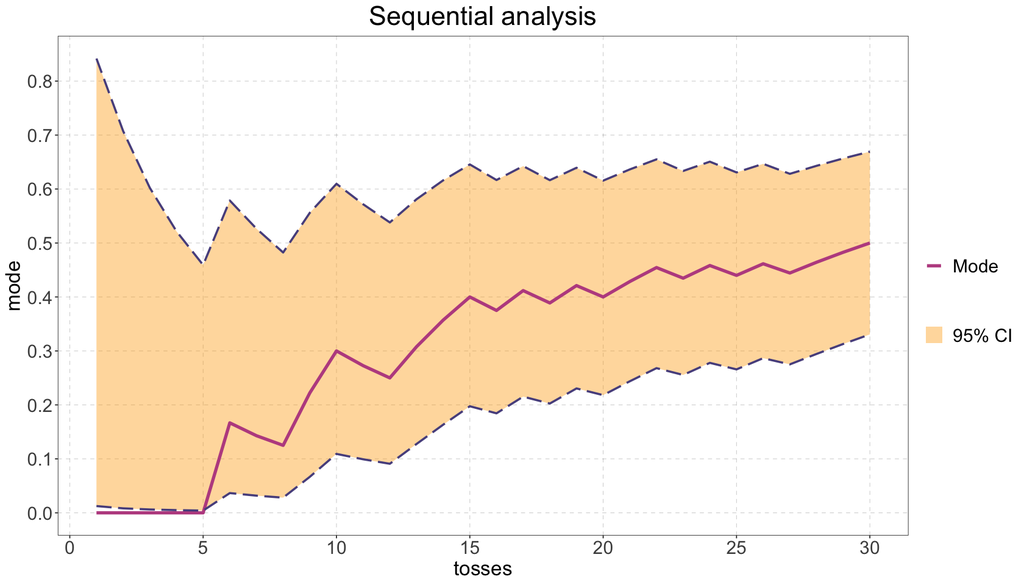

```r
# plot

seqplot <- ggplot() +
        geom_ribbon(
            aes( x = tosses, ymin = pmins, ymax = pmaxs, fill = "95% CI"),
            alpha = 0.4) +
        geom_line(
            aes(x = seq(1, nCoin,1), y = modes, color = "Mode"), linewidth = 1.5
           ) +
        geom_line(
            aes(x = seq(1, nCoin,1), y = pmins), linetype = "longdash", linewidth = 1, color = color_palette[1]
           ) +
        geom_line(
            aes(x = seq(1, nCoin,1), y = pmaxs), linetype = "longdash", linewidth = 1, color = color_palette[1]
           )

seqplot <- seqplot +
        theme_bw() +
        theme( legend.position = "right",
        plot.title = element_text(size = 26, hjust = 0.5),
        axis.title = element_text(size = 20),
        axis.text  = element_text(size = 18),
        legend.title = element_text(size = 20, hjust = 0.5),
        legend.text  = element_text(size = 18),
        panel.grid.major.y = element_line( color = alpha("black",0.2),
                                           linewidth = 0.3,
                                           linetype = 2 ),
        panel.grid.major.x = element_line( color = alpha("black",0.2),
                                          linewidth = 0.3,
                                          linetype = 2 ),
        panel.grid.minor = element_blank(),
        panel.background = element_blank(),
        legend.background = element_rect( fill = "white",
                                          linewidth = 0.5,
                                          linetype = "solid",
                                          colour = "white" ) ) +
        labs( x = "tosses",
              y = "mode",
              title = "Sequential analysis" ) +
        scale_color_manual(
                name = "",
                values = c("Mode" = color_palette[2])) +
        scale_fill_manual( name = "", values = c("95% CI" = color_palette[4])) +
        scale_x_continuous(n.breaks = 8) +
        scale_y_continuous(n.breaks = 7)

seqplot
```

We can observe that until the toss nr. 5, the CI does not include the mode. We may use the mean as our estimate instead the mode, although we search for the probability of a parameter and the most suitable estimate is the mode.

#### 4. Do you get a different result, by analyzing the data sequentially with respect to a one-step analysis (i.e. considering all the data as a whole)?

We summarize our results:

- **one-step analysis**

| prior | mean | $95\%\,\text{CI}$ |
| --- | --- | --- |
| $\mathcal{U}[0,1]$ | 0.5 | 0.33 - 0.67 |
| Jeffereys | 0.5 | 0.33 - 0.67 |

where the mean is the same as the mode, because in this case, where the number of tosses is really high, the posterior distribution is symmetrical and the two values are the same

- **sequential analysis** (final result, i.e., corresponding to the last toss)

| mode | $95\%\,\text{CI}$ |
| --- | --- |
| 0.5 | 0.33 - 0.67 |

So, we get exactly the same results from the two different analysis. In particular, this is because the total number of tosses is very high.

# Exercise 4: Six Boxes Toy Model - inference

Labeling the boxes as follows:

[figure not shown]

Simulate the process in 4 different cases:

**1. After selecting a random box**

```r
# selecting a random box
box <- sample(0:5, 1)
box
```

2

**2. Make random sampling from the box**

The extraction of a stone follows a binomial distribution, so we have to use the random sampling for the binomial distribution to perform random sampling from the chosen box.

```r
# function for random sampling from the box, it returns
# 1 if the stone is white
# 0 if the stone is black
# n is the number of sampling

rstone <- function(n = 1, box) {
    p <- box/5
    s <- rbinom(n = n, size = 1, prob = p)
    return(s)
}
```

**3. Print on the standar output the probability of selecting each box**

The probability of selecting the box $H_j$ after we extracted a stone $E_k$ is, from Bayes' theorem:

$$ P(H_j|E_k I) = \frac{P(E_k|H_jI)P(H_j|I)}{\sum_j P(E_k|H_jI)P(H_j|I)} $$

where $I$ is the information background.

Moreover, at the first extraction, we have that the likelihood (i.e., the probability of selecting a white - or black - stone) multiplied by the prior is

$$ P(E_w|H_jI)P(H_j|I) = \frac{j}{5}\frac{1}{6} $$

and similarly

$$ P(E_b|H_jI)P(H_j|I) = \frac{5-j}{5}\frac{1}{6} $$

Then, the evidence is

$$ \sum_j P(E_k|H_jI)P(H_j|I)=\frac{1}{2} $$

But we want to update the prior every time we extract a stone from the box with the posterior of the previous extraction:

```r
# sampling

nSamples <- 30
sampling <- rstone(nSamples, box)
```

```r
sampling
```

1. 0

2. 0

3. 1

4. 0

5. 0

6. 0

7. 0

8. 0

9. 0

10. 0

11. 1

12. 0

13. 0

14. 0

15. 1

16. 0

17. 0

18. 0

19. 1

20. 0

21. 1

22. 0

23. 1

24. 1

25. 1

26. 1

27. 1

28. 0

29. 1

30. 1

```r
# stone likelihood

l_box <- function(stone, box_n) {
    ifelse(
        stone == 1,
        box_n/5,
        (5-box_n)/5
    )
}
```

```r
# before extracting the first stone each box is equiprobable

# box probabilities (posteriors)
post_box <- array(rep(1/6, 6))
post_box
```

1. 0.166666666666667

2. 0.166666666666667

3. 0.166666666666667

4. 0.166666666666667

5. 0.166666666666667

6. 0.166666666666667

```r
# create matrix to store the posterior at each iteration for all the 6 boxes

posteriors_boxes <- post_box

for(x in sampling) {

    prior_box <- post_box

    likelihoods_boxes <- c()
    for(box in 0:5) {
        likelihoods_boxes <- c(likelihoods_boxes, l_box(x, box))
    }

    evid_box <- sum(likelihoods_boxes * prior_box)

    post_box <- likelihoods_boxes * prior_box / evid_box

    posteriors_boxes <- rbind(posteriors_boxes, post_box)
}
```

```r
# create a tibble to organize our results

post_tibble <- as_tibble(posteriors_boxes)
```

```r
# modifing the tibble to get all our data together

post_tibble <- post_tibble %>% transmute(
    Extraction = seq(0, nSamples, 1),
    Outcome = c("-", sampling),
    Box0 = V1,
    Box1 = V2,
    Box2 = V3,
    Box3 = V4,
    Box4 = V5,
    Box5 = V6
)
```

```r
post_tibble
```

A tibble: 31 × 8

| Extraction <dbl> | Outcome <chr> | Box0 <dbl> | Box1 <dbl> | Box2 <dbl> | Box3 <dbl> | Box4 <dbl> | Box5 <dbl> |
| --- | --- | --- | --- | --- | --- | --- | --- |
| 0 | - | 0.1666667 | 0.16666667 | 0.16666667 | 0.1666666667 | 1.666667e-01 | 0.1666667 |
| 1 | 0 | 0.3333333 | 0.26666667 | 0.20000000 | 0.1333333333 | 6.666667e-02 | 0.0000000 |
| 2 | 0 | 0.4545455 | 0.29090909 | 0.16363636 | 0.0727272727 | 1.818182e-02 | 0.0000000 |
| 3 | 1 | 0.0000000 | 0.32000000 | 0.36000000 | 0.2400000000 | 8.000000e-02 | 0.0000000 |
| 4 | 0 | 0.0000000 | 0.43835616 | 0.36986301 | 0.1643835616 | 2.739726e-02 | 0.0000000 |
| 5 | 0 | 0.0000000 | 0.54468085 | 0.34468085 | 0.1021276596 | 8.510638e-03 | 0.0000000 |
| 6 | 0 | 0.0000000 | 0.63602484 | 0.30186335 | 0.0596273292 | 2.484472e-03 | 0.0000000 |
| 7 | 0 | 0.0000000 | 0.71234783 | 0.25356522 | 0.0333913043 | 6.956522e-04 | 0.0000000 |
| 8 | 0 | 0.0000000 | 0.77480375 | 0.20684763 | 0.0181594628 | 1.891611e-04 | 0.0000000 |
| 9 | 0 | 0.0000000 | 0.82507869 | 0.16520206 | 0.0096688908 | 5.035881e-05 | 0.0000000 |
| 10 | 0 | 0.0000000 | 0.86501897 | 0.12989936 | 0.0050684705 | 1.319914e-05 | 0.0000000 |
| 11 | 1 | 0.0000000 | 0.75873806 | 0.22787844 | 0.0133371925 | 4.630970e-05 | 0.0000000 |
| 12 | 0 | 0.0000000 | 0.81033443 | 0.18253112 | 0.0071220800 | 1.236472e-05 | 0.0000000 |
| 13 | 0 | 0.0000000 | 0.85226869 | 0.14398274 | 0.0037453214 | 3.251147e-06 | 0.0000000 |
| 14 | 0 | 0.0000000 | 0.88581521 | 0.11223758 | 0.0019463713 | 8.447792e-07 | 0.0000000 |
| 15 | 1 | 0.0000000 | 0.79364674 | 0.20111867 | 0.0052315581 | 3.027522e-06 | 0.0000000 |
| 16 | 0 | 0.0000000 | 0.83797364 | 0.15926369 | 0.0027618760 | 7.991539e-07 | 0.0000000 |
| 17 | 0 | 0.0000000 | 0.87397937 | 0.12458015 | 0.0014402736 | 2.083729e-07 | 0.0000000 |
| 18 | 0 | 0.0000000 | 0.90274566 | 0.09651045 | 0.0007438395 | 5.380783e-08 | 0.0000000 |
| 19 | 1 | 0.0000000 | 0.82217401 | 0.17579344 | 0.0020323515 | 1.960216e-07 | 0.0000000 |
| 20 | 0 | 0.0000000 | 0.86088336 | 0.13805257 | 0.0010640190 | 5.131265e-08 | 0.0000000 |
| 21 | 1 | 0.0000000 | 0.75504111 | 0.24215910 | 0.0027996062 | 1.800158e-07 | 0.0000000 |
| 22 | 0 | 0.0000000 | 0.80489615 | 0.19361157 | 0.0014922315 | 4.797555e-08 | 0.0000000 |
| 23 | 1 | 0.0000000 | 0.67265479 | 0.32360386 | 0.0037411907 | 1.603734e-07 | 0.0000000 |
| 24 | 1 | 0.0000000 | 0.50534257 | 0.48622506 | 0.0084318864 | 4.819322e-07 | 0.0000000 |
| 25 | 1 | 0.0000000 | 0.33620241 | 0.64696720 | 0.0168291017 | 1.282510e-06 | 0.0000000 |
| 26 | 1 | 0.0000000 | 0.20004555 | 0.76991068 | 0.0300407154 | 3.052453e-06 | 0.0000000 |
| 27 | 1 | 0.0000000 | 0.10931443 | 0.84143185 | 0.0492470403 | 6.672024e-06 | 0.0000000 |
| 28 | 0 | 0.0000000 | 0.14289216 | 0.82491862 | 0.0321870395 | 2.180361e-06 | 0.0000000 |
| 29 | 1 | 0.0000000 | 0.07563236 | 0.87325353 | 0.0511094889 | 4.616233e-06 | 0.0000000 |
| 30 | 1 | 0.0000000 | 0.03828544 | 0.88408966 | 0.0776155533 | 9.347031e-06 | 0.0000000 |

**4. Plot the probability for each box as a function of the number of trial**

```r
# function to create plot for each box

plotbox <- function(box, title, data = post_tibble) {
    plot <- ggplot(data, aes_string("Extraction", box)) +
        geom_point( color = color_palette[1], size = 2.5) +
        theme_bw() +
        theme( plot.title = element_text(size = 20, hjust = 0.5),
        axis.title = element_text(size = 16),
        axis.text  = element_text(size = 14),
        panel.grid.major.y = element_line( color = alpha("black",0.2),
                                           linewidth = 0.3,
                                           linetype = 2 ),
        panel.grid.major.x = element_line( color = alpha("black",0.2),
                                          linewidth = 0.3,
                                          linetype = 2 ),
        panel.grid.minor = element_blank(),
        panel.background = element_blank() ) +
        labs( x = "Extraction",
              y = "probability",
              title = title ) +
        ylim(-0.05, 1.05) +
        scale_x_continuous(n.breaks = 6)
}
```

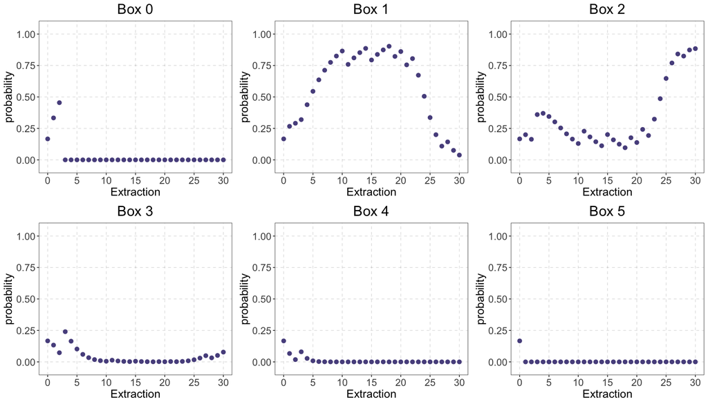

```r
# plot

pb0 <- plotbox("Box0", "Box 0")
pb1 <- plotbox("Box1", "Box 1")
pb2 <- plotbox("Box2", "Box 2")
pb3 <- plotbox("Box3", "Box 3")
pb4 <- plotbox("Box4", "Box 4")
pb5 <- plotbox("Box5", "Box 5")

grid.arrange(pb0, pb1, pb2, pb3, pb4, pb5, ncol = 3, nrow = 2)
```

As expected, the selected box has the higher probability at the end of extractions.